# L04 Maps

Data Visualization (STAT 302)

Author

Shuo Han

## Overview

The goal of this lab is to explore various ways of building maps with `ggplot2`.

Challenges are not mandatory for students to complete. We highly recommend students attempt them though. *We would expect graduate students to attempt the challenges.*

## Datasets

We’ll be using the `US_income.rda` dataset which should be placed in the `/data` subdirectory in our **data_vis_labs** project. You’ll also be downloading your own data to build maps.

```r
library(tidyverse)
library(maps)
library(rgdal)
library(mapproj)
library(rgeos)
library(geodata)
library(sf)
library(viridis)
library(statebins)
library(tidycensus)
library(tigris)
library(mapview)
library(raster)
# Load data-sets
load(file = "data/US_income.rda")
```

## Exercise 1

### Plot 1

Make a county map of a US state using `geom_polygon()`. Maybe use your home state or a favorite state. Please do NOT use the state in the ggplot2 book example.

Optional: Consider adding major cities (or your home town).

*Hints:*

- See section [6.1](https://ggplot2-book.org/maps.html#polygonmaps) in our book.
- Void theme

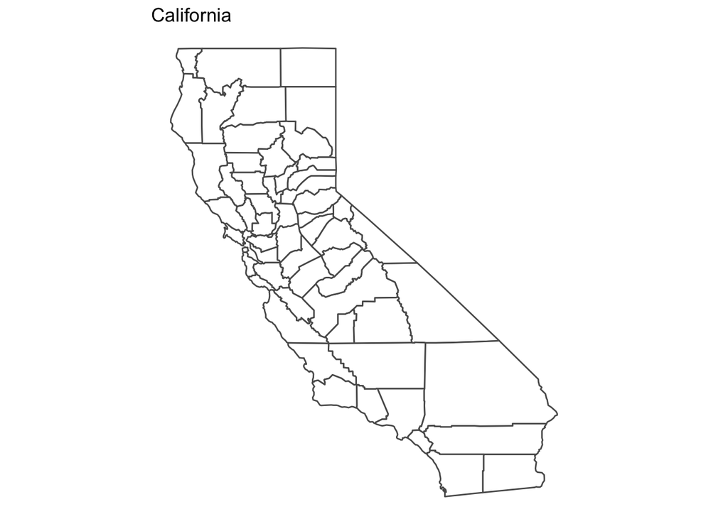

```r
#the best state in the union
ca <- map_data("county", "california") %>%
  dplyr::select(long, lat, group, id = subregion)

ggplot(ca, aes(x = long, y = lat)) +
#add title
  ggtitle("California") +
  geom_polygon(aes(group = group), fill = "white" , color = "grey35") +
  coord_quickmap() +
  theme_void()
```

### Plot 2

Now use `geom_sf()` instead. You’ll need to download data for this. You can use either the `tigris` ([github page](https://github.com/walkerke/tigris)) or `geodata` packages. Either `tigris`’ `counties()` with `cb = TRUE` or `geodata`’s `gadm()` could be useful.

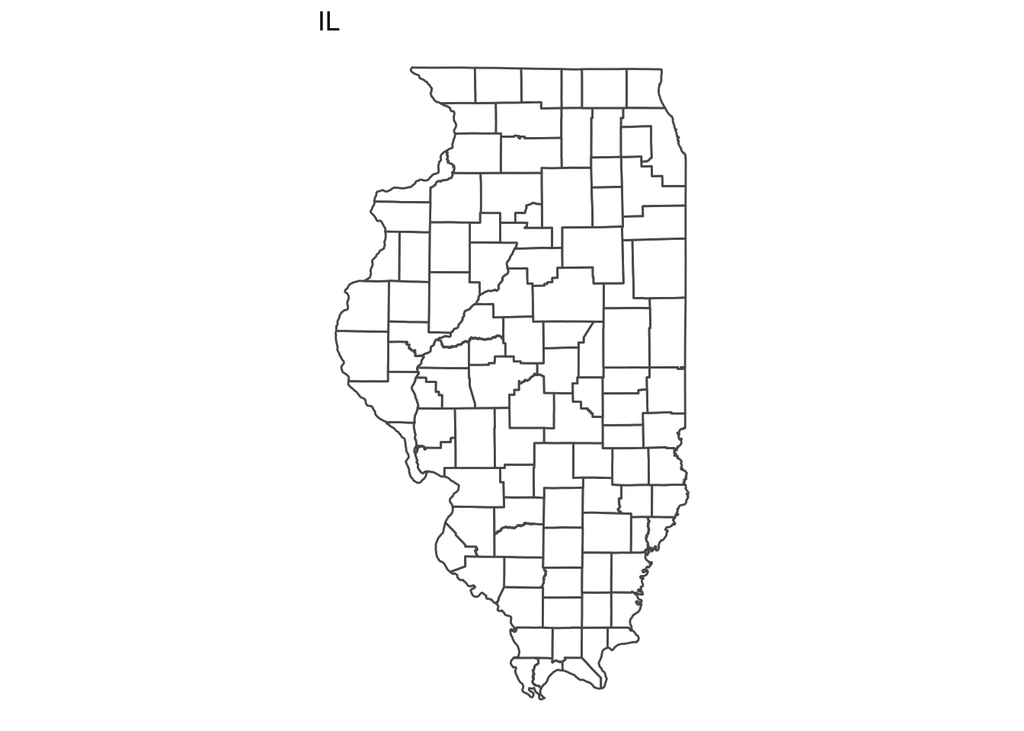

```r
il_data = tigris::counties(state = "IL", cb = TRUE, progress_bar = FALSE)

ggplot(data = il_data) +
  geom_sf(fill = "white") +
  ggtitle("IL")+
  theme_void()
```

## Exercise 2

Using the `US_income` dataset, recreate the following graphics as precisely as possible.

```r
# Setting income levels
US_income <- mutate(
  US_income,
  income_bins = cut(
    ifelse(is.na(median_income), 25000, median_income),
    breaks = c(0, 40000, 50000, 60000, 70000, 80000),
    labels = c("< $40k", "$40k to $50k",
               "$50k to $60k", "$60k to $70k", "> $70k"),
    right = FALSE
  )
)
```

### Plot 1

*Hints:*

- `geom_sf()` — boundary color is `"grey80"` and size is 0.2
- `viridis` package (`discrete = TRUE` in `scale_*` function)
- Void theme

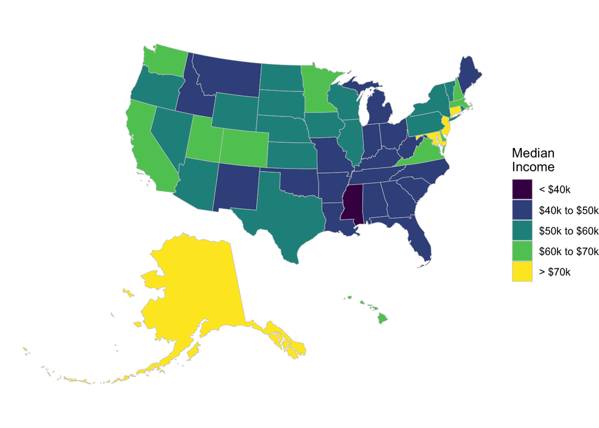

```r
# Setting income levels
US_income <- mutate(
  US_income, income_bins = cut(ifelse(is.na(median_income),
                                      25000, median_income),
    breaks = c(0, 40000, 50000, 60000, 70000, 80000),
    labels = c("< $40k", "$40k to $50k", "$50k to $60k",
               "$60k to $70k", "> $70k"),
    right = FALSE)
)

ggplot(US_income) +
#specify geometry shape to be used
  geom_sf(aes(geometry = geometry, fill = income_bins),
          color = "grey80",
          size = 0.2) +
  viridis::scale_fill_viridis(discrete = TRUE,
                              name = "Median\nIncome") +
#helps size correctly
  coord_sf() +
#shows just the plotted features
  theme_void()
```

### Plot 2

*Hints:*

- `statebins::geom_statebins()`
- `viridis` package (`discrete = TRUE` in `scale_*` function)
- Statebins theme

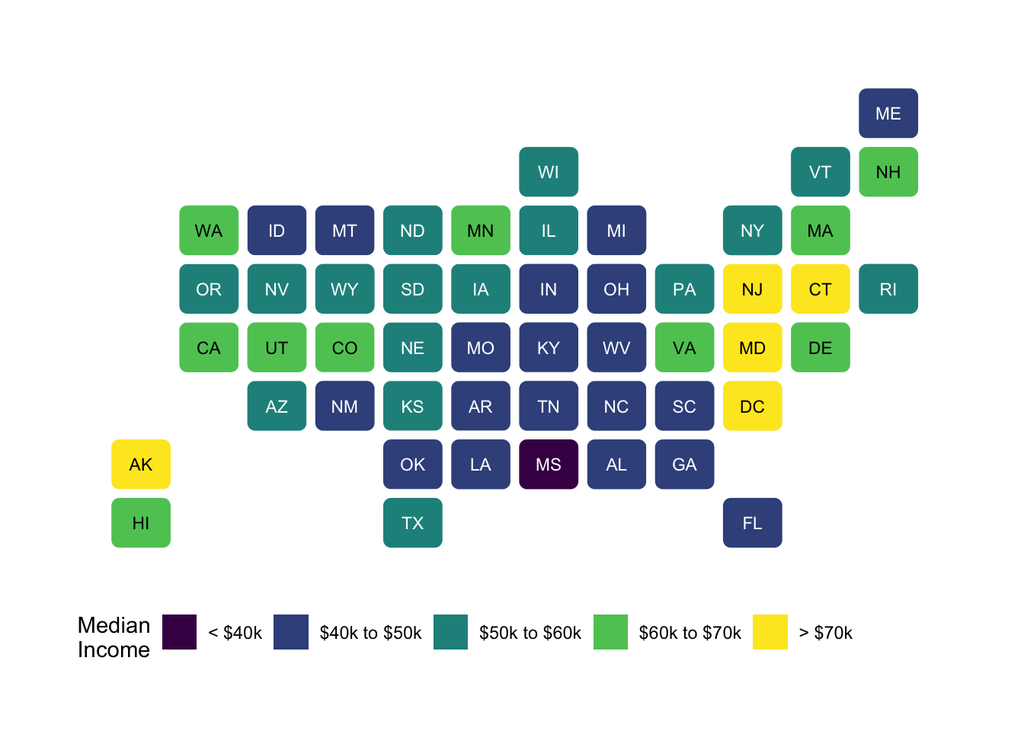

```r
ggplot(US_income, aes(state = name, fill = income_bins)) +
  geom_statebins() +
#scale color fill to viridis color pallet
  viridis::scale_fill_viridis(
#change to continous scale
      discrete = TRUE,
#change legend name
      name = "Median\nIncome") +
  theme_statebins()
```

## Exercise 3

Pick any city or foreign country to build a map for. You can dress it up or make it as basic as you want. Also welcome to try building a graphic like that depicted at the end of section [6.5](https://ggplot2-book.org/maps.html#rastermaps) — use a different region though.

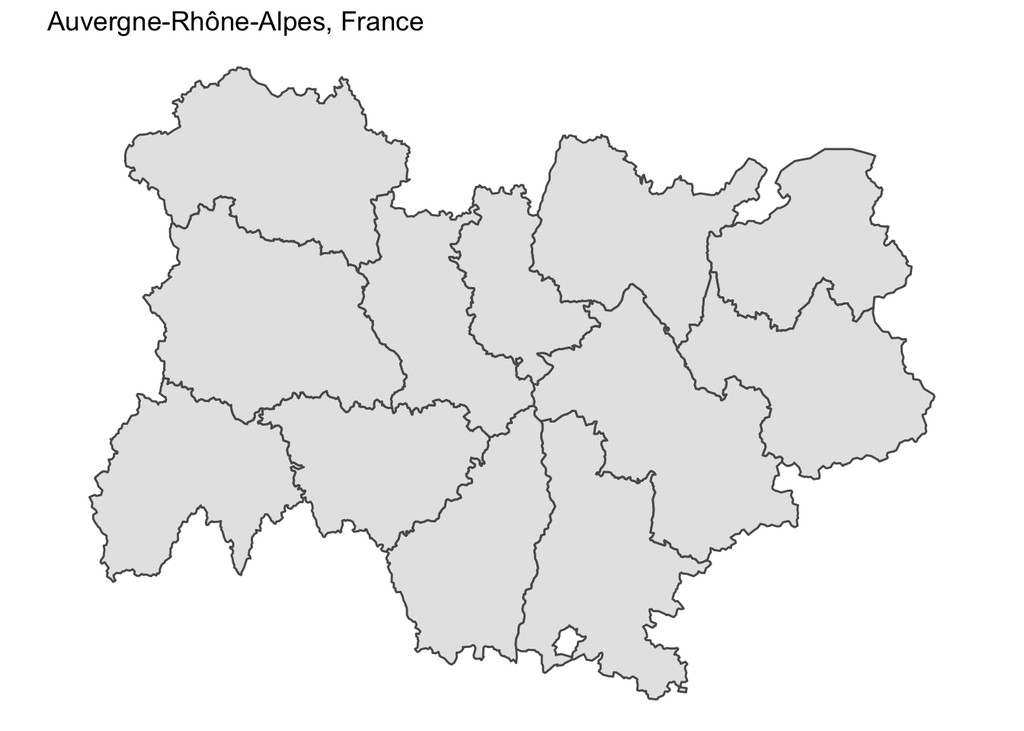

```r
state_level_map <- raster::getData("GADM",
                                   country = "France",
                                   level = 2) %>%
  st_as_sf() %>%
  filter(NAME_1 == "Auvergne-Rhône-Alpes")

ggplot() +
  geom_sf(data = state_level_map) +
  labs(title = "Auvergne-Rhône-Alpes, France") +
  coord_sf() +
  theme_void()
```

## Challenge(s)

```r
#GET CENSUS KEY
#install census key; ONLY NEED TO DO THIS ONCE
census_api_key("14a0a9fdbf4c3b987cab4d1241bbef1494bb245d", install = TRUE, overwrite = TRUE)
```

```
[1] "14a0a9fdbf4c3b987cab4d1241bbef1494bb245d"
```

```r
mapview(ny,zcol = "estimate", legend = TRUE, lwd = 0.2)
```

[output not shown]

[interactive chart not shown]